# Aufgabenblatt 2

1. Gegeben sei der nachstehende zweidimensionale Datensatz. Führen Sie ein $K$-means Clustering mit $K=3$ unter Verwendung der euklidischen Distanz durch. Verwenden Sie die ersten drei Punkte als Anfangszentroiden. Geben Sie bei jeder Algorithmeniteration jeweils die Distanzen zwischen Zentroiden und allen Punkten an und berechnen Sie nach jeder Neuzuordnung der Punkte die veränderten Zentroiden.

|  | p1 | p2 | p3 | p4 | p5 | p6 | p7 | p8 | p9 | p10 | p11 | p12 |
| --- | --- | --- | --- | --- | --- | --- | --- | --- | --- | --- | --- | --- |
| x | 2.0 | 2.0 | 2.0 | 2.5 | 2.5 | 3.0 | 4.0 | 4.0 | 4.5 | 4.5 | 4.5 | 4.5 |
| y | 1.0 | 1.5 | 2.0 | 1.0 | 2.0 | 4.0 | 1.0 | 2.5 | 1.0 | 1.5 | 2.5 | 3.0 |

```r
 dat <- tibble(
   x = c(2.0, 2.0, 2.0, 2.5, 2.5, 3.0, 4.0, 4.0, 4.5, 4.5, 4.5 , 4.5),
   y = c(1.0, 1.5, 2.0, 1.0, 2.0, 4.0, 1.0, 2.5, 1.0, 1.5, 2.5 , 3.0)
 )

# LÃ¶sung zu Aufgabe 1...

#create inital centers
centers<- dat[1:3,1:2]
curCenters <- dat[2:4,1:2]

while(!isTRUE(all.equal(curCenters, centers))){
  curCenters <- centers
  print(rdist(centers, dat))
  dat <- mutate(dat,cluster=(apply(rdist(centers, dat),2,which.min)))
  for(i in 1:3){
    current <- filter(dat, cluster==i)
    centers[i,1] <- sum(current$x)/nrow(current)
    centers[i,2] <- sum(current$y)/nrow(current)
  }
}
```

```
##      [,1] [,2] [,3]      [,4]      [,5]     [,6]     [,7]     [,8]
## [1,]  0.0  0.5  1.0 0.5000000 1.1180340 3.162278 2.000000 2.500000
## [2,]  0.5  0.0  0.5 0.7071068 0.7071068 2.692582 2.061553 2.236068
## [3,]  1.0  0.5  0.0 1.1180340 0.5000000 2.236068 2.236068 2.061553
##          [,9]   [,10]    [,11]    [,12]
## [1,] 2.500000 2.54951 2.915476 3.201562
## [2,] 2.549510 2.50000 2.692582 2.915476
## [3,] 2.692582 2.54951 2.549510 2.692582
##          [,1]     [,2]     [,3]      [,4]      [,5]     [,6]      [,7]
## [1,] 1.250000 1.346291 1.600781 0.7500000 1.2500000 3.010399 0.7500000
## [2,] 1.346291 1.250000 1.346291 0.9013878 0.9013878 2.512469 0.9013878
## [3,] 2.187401 1.835226 1.565691 1.9021187 1.1334559 1.396921 1.7658017
##           [,8]     [,9]    [,10]    [,11]    [,12]
## [1,] 1.6770510 1.250000 1.346291 1.952562 2.358495
## [2,] 1.2500000 1.346291 1.250000 1.600781 1.952562
```

[output cut: 25 more lines]

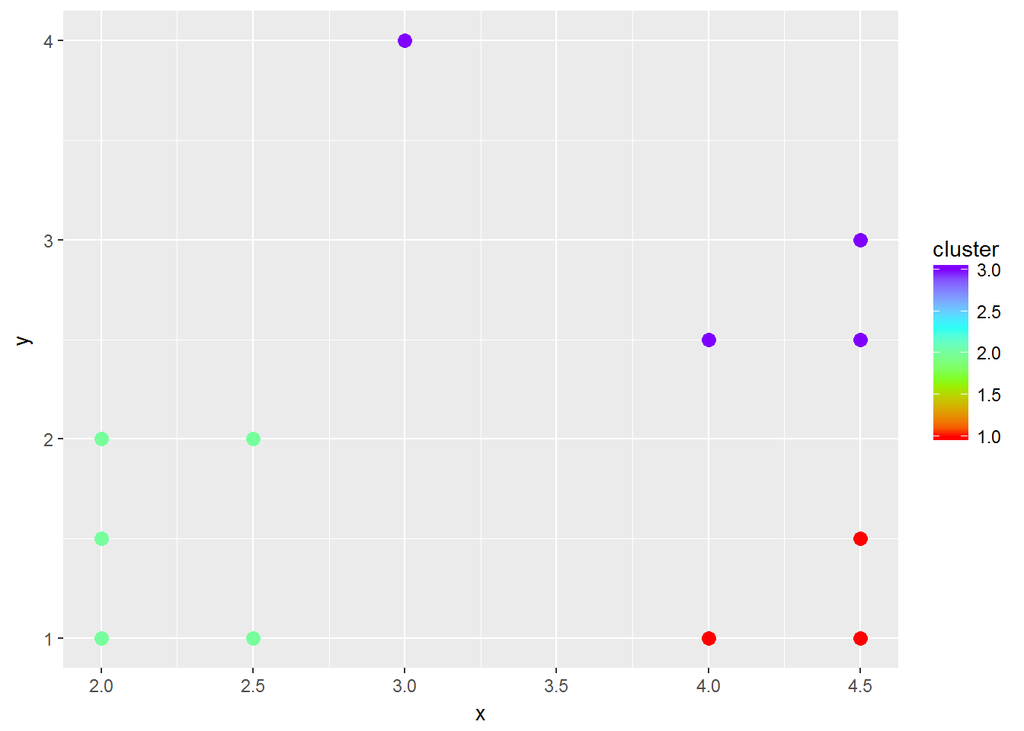

```r
ggplot(dat, aes(x=x, y=y)) + geom_point( aes(colour=cluster), size=3) +  scale_colour_gradientn(colours=rainbow(4))
```

2. Eine Schule möchte ihre Schüler nach den Leistungen bei zwei Zwischenprüfungen gruppieren. Es wird davon ausgegangen, dass es mindestens 2 Cluster von Schülern gibt. Laden Sie die Datei `clustering-student-mat.csv` ein. Die Datei enthält zu jeder der beiden Prüfungen die Anzahl der erzielten Punktzahl für insgesamt 395 Schüler.  
   Führen Sie je ein $K$-means-Clustering für alle $k\in \{2,3,\ldots,8\}$ durch. Stellen Sie die Clusterzuordnungen der Punkte in einem Streudiagramm (Scatter Plot) dar.

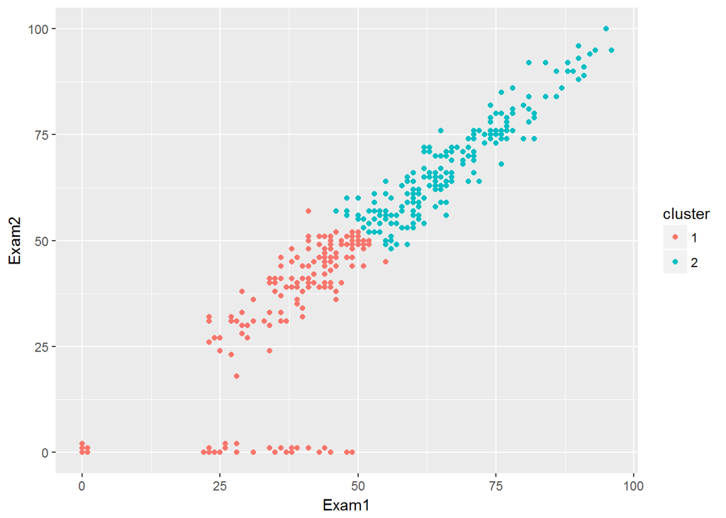

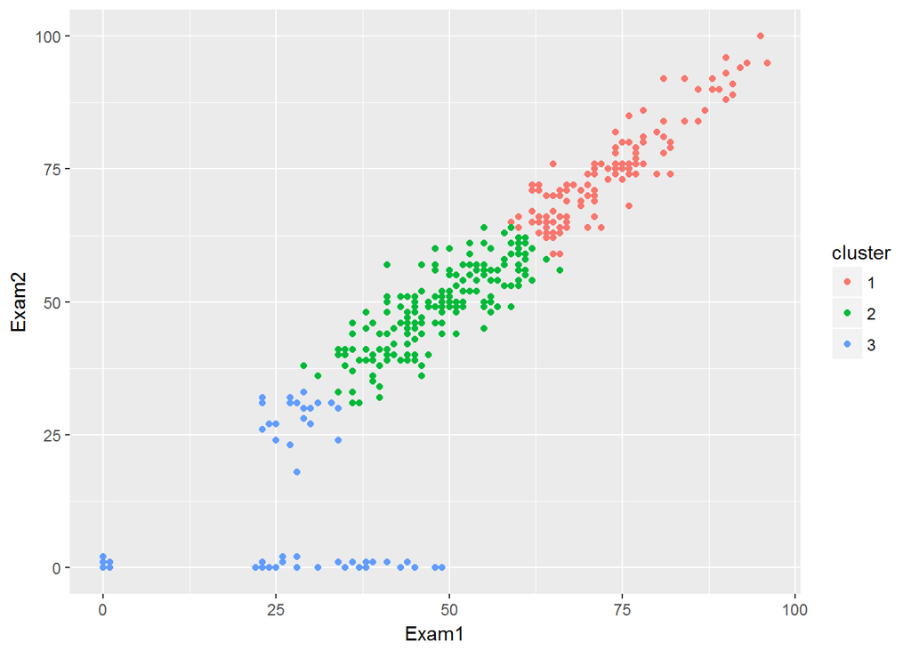

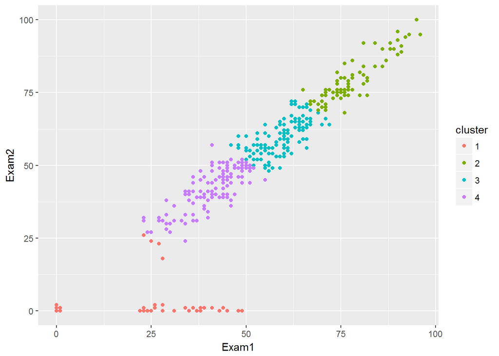

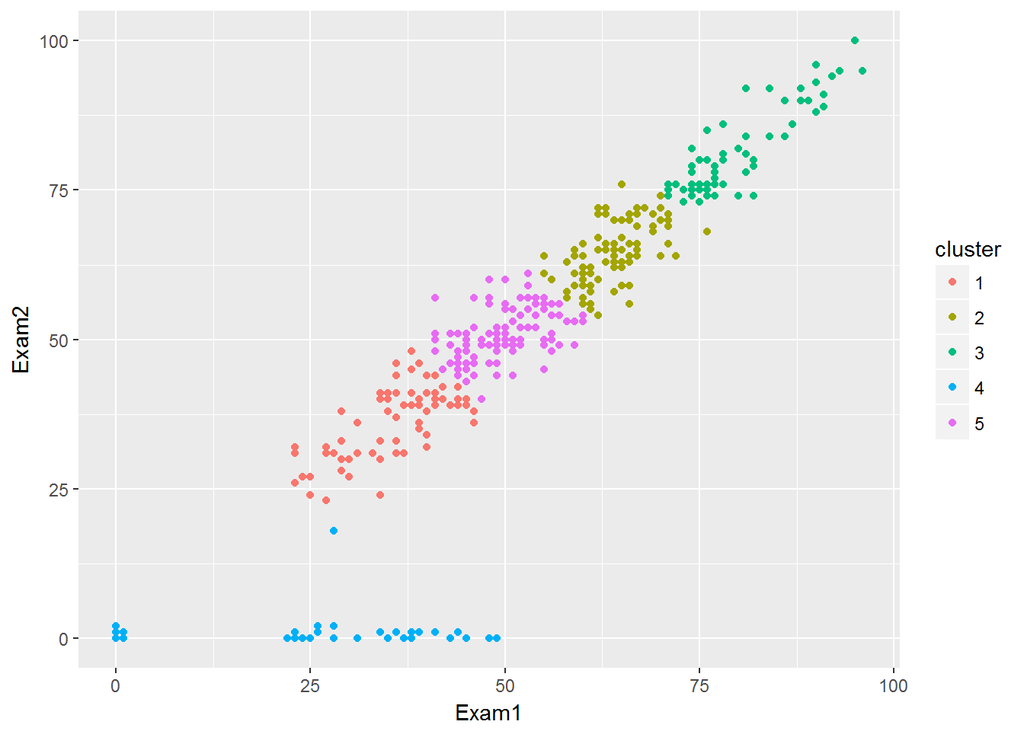

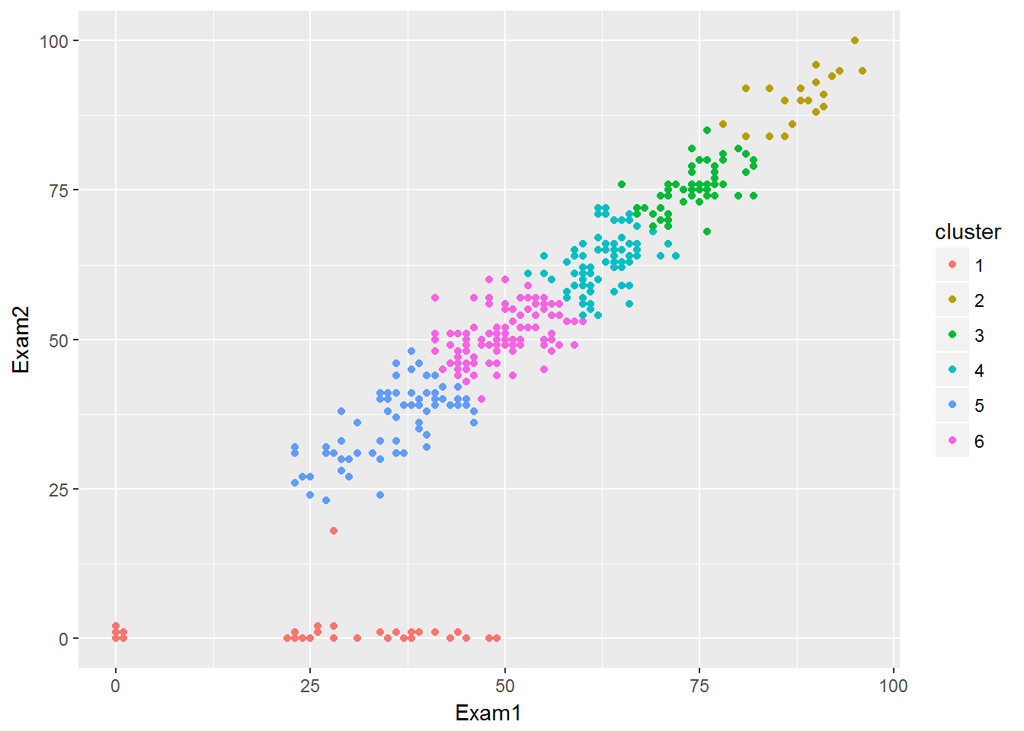

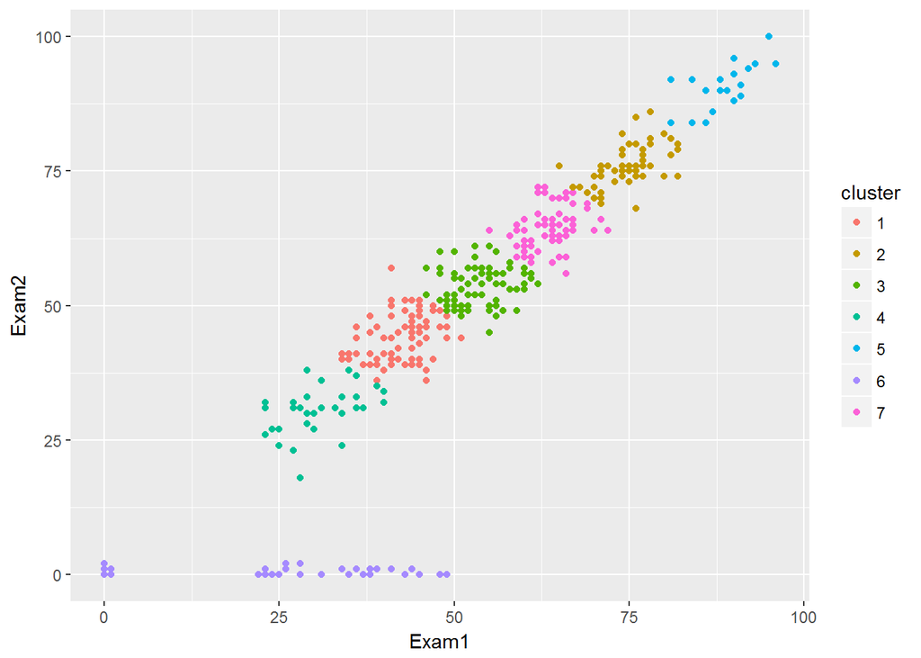

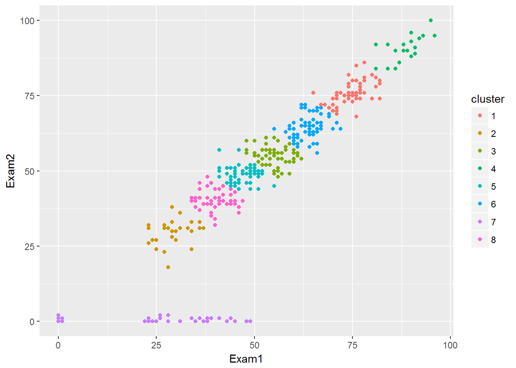

```r
# LÃ¶sung zu Aufgabe 2...
 student <- read_csv(str_c(dirname(getwd()), "/visualAnalytics/Data/clustering-student-mat.csv"))
k<-c(2:8)
for (j in k){
  clust<-kmeans(student,centers=j)
  student<-student %>% mutate(cluster = factor(clust$cluster))
  plt<-ggplot(student, aes(Exam1, Exam2, color = cluster,
                                         fill = cluster))+
    geom_point()
  print(plt)
}
```

3. Ermitteln Sie für das Clustering aus Ausgabe 2 den optimalen Wert für die Anzahl der Cluster $K$ mithilfe des Silhouetten-Koeffizienten. Bewerten Sie das Ergebnis im Hinblick auf die Repräsentativität der Zentroiden bezüglich ihres Clusters.

```r
# LÃ¶sung zu Aufgabe 3...
library(cluster)
k<-c(2:8)
for (j in k){
  clust<-kmeans(student,centers=j)
  student<-student %>% mutate(cluster = factor(clust$cluster))
  si <- silhouette(clust$cluster, dist(student))
  #window(si)
  #pdf(paste0(j, 'plot.pdf',sep=""))
  #plot(si)
  #dev.off()
}
#Repräsentativität der Zentroiden zu ihrem Cluster = Silhouetten-Koeffizienten sollten ähnlich sein
#2 bis 5 relativ durchwachsen, viele Mitglieder eines Clusters haben nahezu gleiche Entfernung zu anderen Clusterelementen wie geringste Entfernung zu Element aus anderem Cluster, die Werte meist im mittleren Bereich ca. um .50 herum -> mittelgute Repräsentativität der Cluster, auch negativ-Werte dabei -> mögliche Falsch-Klassifizierung
#ab 6 stärkere Repräsentativität der Zentroiden, da einzelne Durchschnittswerte für ein Cluster höher werden und Durchwachsenheit der Werte im Cluster abnimmt
# 8 beste Repräsentativität, aufgrund der ähnlichen Silhouettenwerte im jeweiligen Cluster
```

```r
dm <- tribble(~p1,~p2,~p3,~p4,~p5,
              0.00, 0.02, 0.90, 0.36, 0.53,
              0.02, 0.00, 0.65, 0.15, 0.24,
              0.90, 0.65, 0.00, 0.59, 0.45,
              0.36, 0.15, 0.59, 0.00, 0.56,
              0.53, 0.24, 0.45, 0.56, 0.00) %>% as.matrix()
rownames(dm) <- letters[1:5]
colnames(dm) <- letters[1:5]
knitr::kable(dm)
```

|  | a | b | c | d | e |
| --- | --- | --- | --- | --- | --- |
| a | 0.00 | 0.02 | 0.90 | 0.36 | 0.53 |
| b | 0.02 | 0.00 | 0.65 | 0.15 | 0.24 |
| c | 0.90 | 0.65 | 0.00 | 0.59 | 0.45 |
| d | 0.36 | 0.15 | 0.59 | 0.00 | 0.56 |
| e | 0.53 | 0.24 | 0.45 | 0.56 | 0.00 |

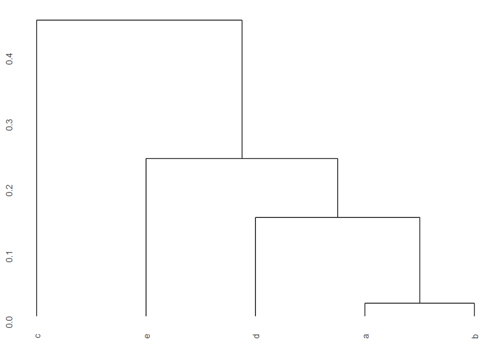

```r
# LÃ¶sung zu Aufgabe 4...


hc <- hclust(as.dist(dm), method = "single")
d_sl <- ggdendrogram(hc, rotate = F, size = 2)
d_sl
```

Datensatz fÃ¼r Aufgabe 2:  
http://isgwww.cs.uni-magdeburg.de/cv/lehre/VisAnalytics/material/exercise/datasets/clustering-student-mat.csv